# MSCA 31008 HW3-Part2

#### Show that Component scores are orthogonal.

```r
round(cov(m1$x),2)
```

```
##       PC1  PC2  PC3  PC4  PC5  PC6  PC7  PC8  PC9 PC10 PC11 PC12 PC13
## PC1  6.46 0.00 0.00 0.00 0.00 0.00 0.00 0.00 0.00 0.00  0.0 0.00 0.00
## PC2  0.00 1.52 0.00 0.00 0.00 0.00 0.00 0.00 0.00 0.00  0.0 0.00 0.00
## PC3  0.00 0.00 1.42 0.00 0.00 0.00 0.00 0.00 0.00 0.00  0.0 0.00 0.00
## PC4  0.00 0.00 0.00 0.92 0.00 0.00 0.00 0.00 0.00 0.00  0.0 0.00 0.00
## PC5  0.00 0.00 0.00 0.00 0.66 0.00 0.00 0.00 0.00 0.00  0.0 0.00 0.00
## PC6  0.00 0.00 0.00 0.00 0.00 0.46 0.00 0.00 0.00 0.00  0.0 0.00 0.00
## PC7  0.00 0.00 0.00 0.00 0.00 0.00 0.41 0.00 0.00 0.00  0.0 0.00 0.00
## PC8  0.00 0.00 0.00 0.00 0.00 0.00 0.00 0.28 0.00 0.00  0.0 0.00 0.00
## PC9  0.00 0.00 0.00 0.00 0.00 0.00 0.00 0.00 0.23 0.00  0.0 0.00 0.00
## PC10 0.00 0.00 0.00 0.00 0.00 0.00 0.00 0.00 0.00 0.21  0.0 0.00 0.00
## PC11 0.00 0.00 0.00 0.00 0.00 0.00 0.00 0.00 0.00 0.00  0.2 0.00 0.00
## PC12 0.00 0.00 0.00 0.00 0.00 0.00 0.00 0.00 0.00 0.00  0.0 0.15 0.00
## PC13 0.00 0.00 0.00 0.00 0.00 0.00 0.00 0.00 0.00 0.00  0.0 0.00 0.07
```

```r
round(t(m1$x) %*% m1$x/353,2)
```

```
##       PC1  PC2  PC3  PC4  PC5  PC6  PC7  PC8  PC9 PC10 PC11 PC12 PC13
## PC1  6.46 0.00 0.00 0.00 0.00 0.00 0.00 0.00 0.00 0.00  0.0 0.00 0.00
## PC2  0.00 1.52 0.00 0.00 0.00 0.00 0.00 0.00 0.00 0.00  0.0 0.00 0.00
## PC3  0.00 0.00 1.42 0.00 0.00 0.00 0.00 0.00 0.00 0.00  0.0 0.00 0.00
## PC4  0.00 0.00 0.00 0.92 0.00 0.00 0.00 0.00 0.00 0.00  0.0 0.00 0.00
## PC5  0.00 0.00 0.00 0.00 0.66 0.00 0.00 0.00 0.00 0.00  0.0 0.00 0.00
## PC6  0.00 0.00 0.00 0.00 0.00 0.46 0.00 0.00 0.00 0.00  0.0 0.00 0.00
## PC7  0.00 0.00 0.00 0.00 0.00 0.00 0.41 0.00 0.00 0.00  0.0 0.00 0.00
## PC8  0.00 0.00 0.00 0.00 0.00 0.00 0.00 0.28 0.00 0.00  0.0 0.00 0.00
## PC9  0.00 0.00 0.00 0.00 0.00 0.00 0.00 0.00 0.23 0.00  0.0 0.00 0.00
## PC10 0.00 0.00 0.00 0.00 0.00 0.00 0.00 0.00 0.00 0.21  0.0 0.00 0.00
## PC11 0.00 0.00 0.00 0.00 0.00 0.00 0.00 0.00 0.00 0.00  0.2 0.00 0.00
## PC12 0.00 0.00 0.00 0.00 0.00 0.00 0.00 0.00 0.00 0.00  0.0 0.15 0.00
## PC13 0.00 0.00 0.00 0.00 0.00 0.00 0.00 0.00 0.00 0.00  0.0 0.00 0.07
```

**From the above result we could see that both the component loadings and component scores are orthogonal since the result t(X) %*% X is a diagonal matrix that has non-zero values on the diagonal and zeroes off the diagonal.**

#### Perform Test validation of Principal Components solution.

```r
pred <- predict(m1, test)
```

*matrix multiply the predicted component scores from (1) above with transpose of component loadings you derived from training data set from Step 2 above.*

```r
head(round(pred[,1:7] %*% t(m1$rotation)[1:7,], 2))
```

```
##    crim    zn indus   nox    rm   age  dis   rad   tax ptratio black lstat  medv
## 6  0.41  0.22 -1.94 -2.20  0.47 -1.10 1.59 -0.57 -1.14    1.57  0.27 -0.79  0.03
## 7  0.17  0.20 -0.55 -0.58 -0.35 -0.59 0.55 -0.36 -0.45   -0.08  0.14 -0.11 -0.11
## 12 0.16  0.26 -0.57 -0.60 -0.37 -0.60 0.60 -0.37 -0.45   -0.06  0.14 -0.08 -0.15
## 13 0.20  0.17 -0.51 -0.56 -0.53 -0.65 0.55 -0.38 -0.45   -0.11  0.17 -0.06 -0.19
## 16 0.05 -0.19 -0.25 -0.48 -0.51 -0.44 0.39 -0.11 -0.16    0.61  0.18  0.00 -0.37
## 28 0.04 -0.11 -0.30 -0.47 -0.27 -0.24 0.38 -0.09 -0.17    0.65  0.11  0.03 -0.33
```

#### Compute the Variance Account For (R^2) in the Test sample.

```r
cor(as.vector(train), as.vector(m1$x[,1:7] %*% t(m1$rotation)[1:7,]))^2
```

```
## [1] 0.9125865
```

```r
cor(as.vector(test), as.vector(pred[,1:7] %*%  t(m1$rotation)[1:7,]))^2
```

```
## [1] 0.3210765
```

**I calculated R^2 for both train set and test set. The result for the test sample is not very similar to that of train sample.**

*Note: I try to add ‘scale=TRUE’ in the prcomp function and I got a R^2 of 0.9160171 for test sample. But I think I have already scaled the sample before, I don’t need to scale it again in the function. Also, from the sample code given in class, I don’t need to scale again if I scale the data before perform PCA. So here I choose not to add the ‘scale=TRUE’ option. Although the R^2 is low here, I think this would be reasonable.*

#### Rotate the component loadings using varimax rotation.

```r
m2 <- prcomp(train)
summary(m2)
```

```
## Importance of components:
##                           PC1    PC2    PC3     PC4     PC5     PC6     PC7     PC8
## Standard deviation     2.5426 1.2342 1.1924 0.96080 0.80999 0.68185 0.64011 0.53321
## Proportion of Variance 0.4973 0.1172 0.1094 0.07101 0.05047 0.03576 0.03152 0.02187
## Cumulative Proportion  0.4973 0.6145 0.7238 0.79484 0.84530 0.88107 0.91259 0.93446
##                            PC9    PC10    PC11    PC12   PC13
## Standard deviation     0.48296 0.45718 0.44515 0.38127 0.2574
## Proportion of Variance 0.01794 0.01608 0.01524 0.01118 0.0051
## Cumulative Proportion  0.95240 0.96848 0.98372 0.99490 1.0000
```

```r
cor(as.vector(scale(train)), as.vector(m2$x[,1:7]  %*% t(m2$rotation)[1:7,]))^2
```

```
## [1] 0.9125865
```

```r
y <- varimax(m2$rotation[, 1:7])
y
```

```
## $loadings
##
## Loadings:
##         PC1    PC2    PC3    PC4    PC5    PC6    PC7
## crim                                        0.915
## zn       0.164        -0.784  0.194                0.116
## indus    0.421  0.113  0.199  0.150        -0.301
## nox      0.283         0.175  0.322        -0.139  0.198
## rm             -0.704 -0.127 -0.135 -0.152         0.282
## age                    0.106                       0.771
## dis             0.108 -0.494 -0.175               -0.168
## rad      0.544               -0.114         0.206
## tax      0.615
## ptratio  0.148               -0.860
## black                                0.976
## lstat           0.410 -0.123                       0.460
## medv           -0.535  0.108  0.165  0.123        -0.155
##
##                  PC1   PC2   PC3   PC4   PC5   PC6   PC7
## SS loadings    1.000 1.000 1.000 1.000 1.000 1.000 1.000
## Proportion Var 0.077 0.077 0.077 0.077 0.077 0.077 0.077
## Cumulative Var 0.077 0.154 0.231 0.308 0.385 0.462 0.538
##
## $rotmat
##             [,1]        [,2]        [,3]        [,4]       [,5]       [,6]        [,7]
## [1,]  0.60552042  0.43112277  0.44460356 -0.04769150 -0.2238879  0.1579169  0.41529244
## [2,] -0.33533663  0.83078216 -0.15442829 -0.34920705  0.1466553 -0.1225133 -0.12263523
## [3,] -0.36154917 -0.01845599  0.59213452  0.24891641  0.3671170 -0.4698357  0.31755061
## [4,] -0.23875163  0.29251011 -0.25347273  0.78850170 -0.3623048  0.1034770  0.17169706
## [5,]  0.51576058  0.11076688 -0.42230570  0.28894173  0.6259306 -0.2555453  0.05291267
## [6,] -0.24061754 -0.03532551 -0.03780813 -0.03950636  0.4704762  0.7503635  0.39175479
## [7,] -0.09627279 -0.15657008 -0.42876136 -0.32716596 -0.2217876 -0.3166241  0.72519166
```

```r
cor(as.vector(scale(train)), as.vector(m2$x[,1:7] %*% y$rotmat %*% t(y$rotmat) %*% t(m2$rotation)[1:7,]))^2
```

```
## [1] 0.9125865
```

**R^2 is the same.**

#### Plot rotated loadings(1) versus rotated loadings (2) and (3).

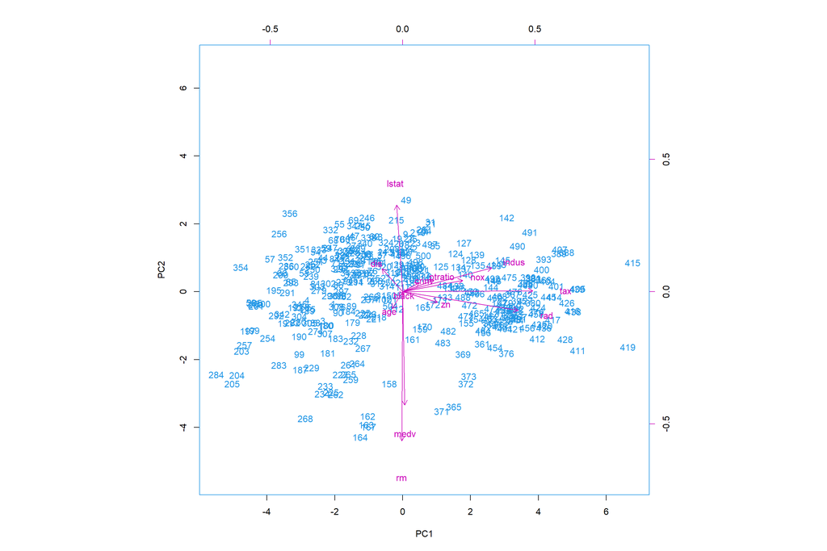

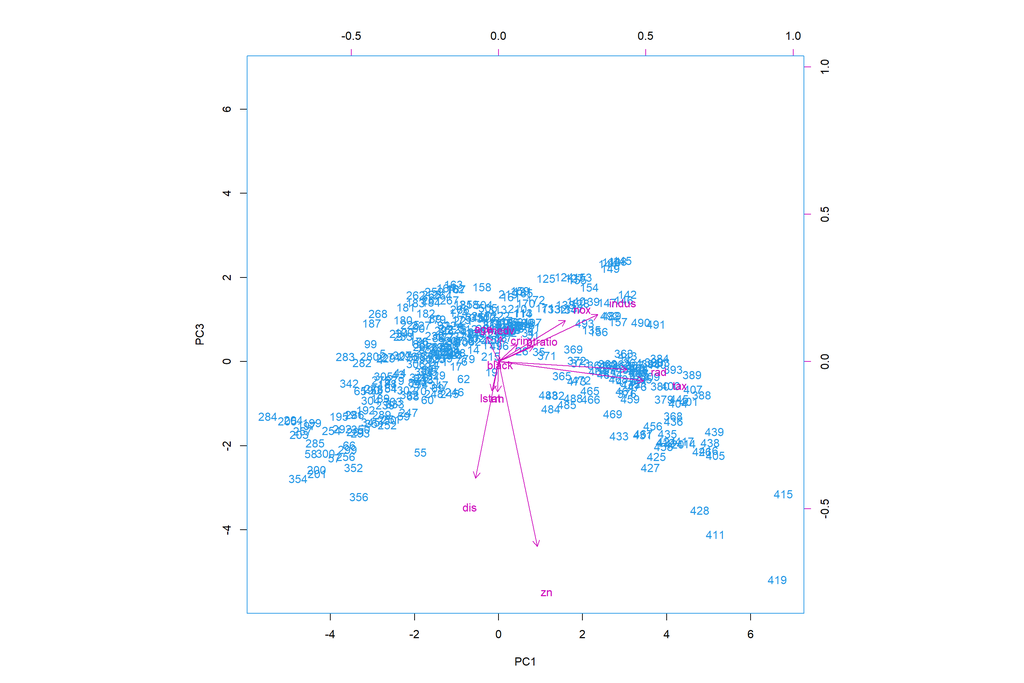

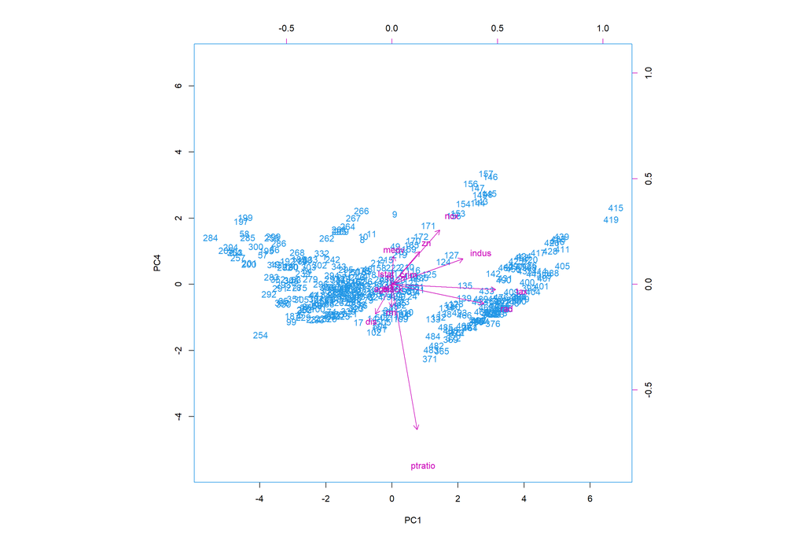

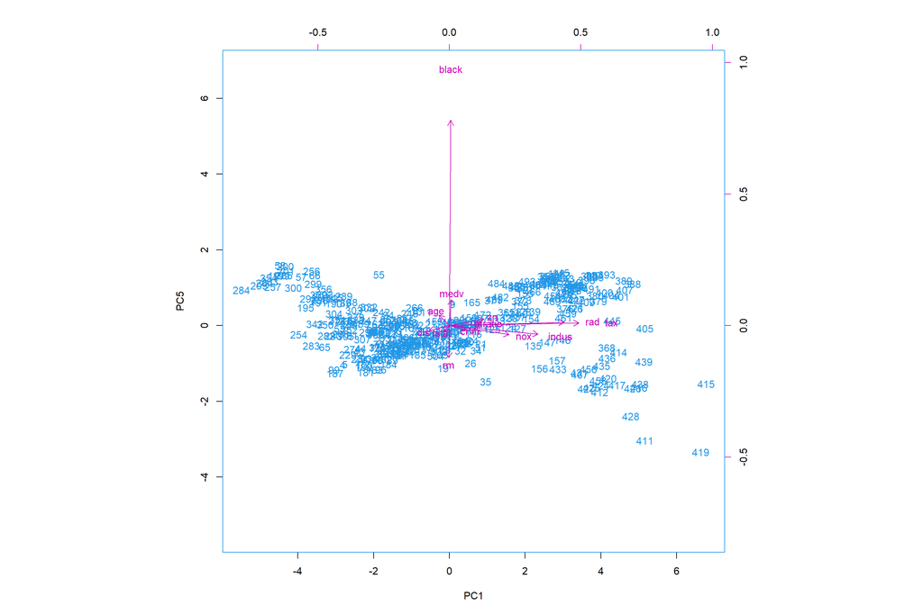

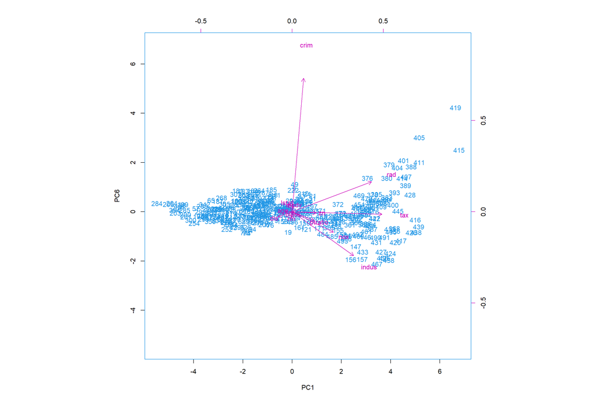

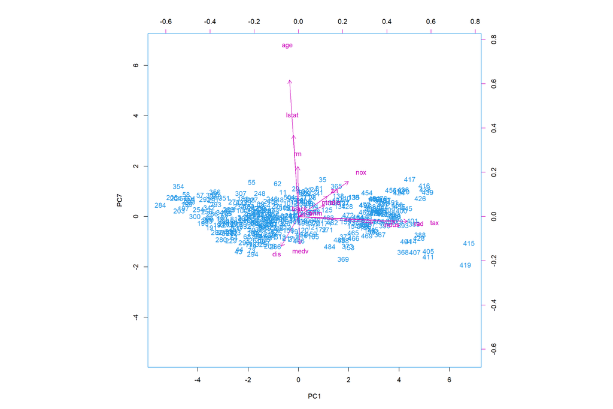

```r
for (i in 2:7) {
  biplot(m2$x[,c(1,i)], y$loadings[,c(1,i)], cex=1,col=c(4,6))
}
```

**This rotated loadings result are clearer and we could distinguish the variables that have more influence on each principal component. The variables that have most impact on each principal component is more outstanding than the previous solution. Personally speaking, I like this solution.**